# Cardio Good Fitness Project! - by Vanika Hans

### 7] UNIVARIATE/BIVARIATE ANALYSIS: Explore Qualitative Factors i.e. Genders/Maritial Status vs Product Lines

First, Gender (overall):

```python
cardiodata.Gender.value_counts()
```

```
Male      104
Female     76
Name: Gender, dtype: int64
```

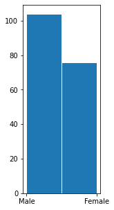

```python
plt.figure(figsize=(2,5))
plt.hist(cardiodata['Gender'],bins=2,ec="white")
```

Next, Gender by Productline (BIVARIATE):

```python
cardiodata[cardiodata['Product'] == "TM195"].Gender.value_counts()
```

```
Female    40
Male      40
Name: Gender, dtype: int64
```

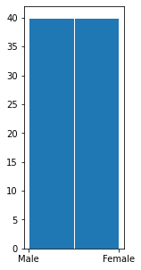

```python
plt.figure(figsize=(2,5))
plt.hist(cardiodata[cardiodata['Product'] == "TM195"].Gender,bins=2,ec="white")
```

```python
cardiodata[cardiodata['Product'] == "TM498"].Gender.value_counts()
```

```
Male      31
Female    29
Name: Gender, dtype: int64
```

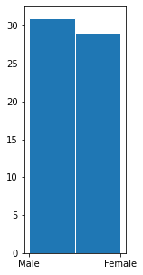

```python
plt.figure(figsize=(2,5))
plt.hist(cardiodata[cardiodata['Product'] == "TM498"].Gender,bins=2,ec="white")
```

```python
cardiodata[cardiodata['Product'] == "TM798"].Gender.value_counts()
```

```
Male      33
Female     7
Name: Gender, dtype: int64
```

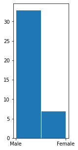

```python
plt.figure(figsize=(2,5))
plt.hist(cardiodata[cardiodata['Product'] == "TM798"].Gender,bins=2,ec="white")
```

**OBSERVATION 15:** More men tend to buy treadmills than women. TM198 and TM498 were purchased by about the same number of men & women, but many more men purchased TM798 than women.</font>

#### Next, Maritial Status (UNIVARIATE):

```python
cardiodata.MaritalStatus.value_counts()
```

```
Partnered    107
Single        73
Name: MaritalStatus, dtype: int64
```

#### Next, Maritial Status (BIVARIATE):

```python
cardiodata[cardiodata['Product'] == "TM195"].MaritalStatus.value_counts()
```

```
Partnered    48
Single       32
Name: MaritalStatus, dtype: int64
```

```python
cardiodata[cardiodata['Product'] == "TM498"].MaritalStatus.value_counts()
```

```
Partnered    36
Single       24
Name: MaritalStatus, dtype: int64
```

```python
cardiodata[cardiodata['Product'] == "TM798"].MaritalStatus.value_counts()
```

```
Partnered    23
Single       17
Name: MaritalStatus, dtype: int64
```

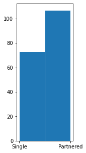

```python
plt.figure(figsize=(2,5))
plt.hist(cardiodata['MaritalStatus'],bins=2,ec="white")
```

**OBSERVATION 16:** From both overall data and by product-line, it's evident that more partnered folks seem to buy treadmills than singles.</font>

### 8] MULTIVARIATE ANALYSIS: HeatMap

First, an overall heatmap:

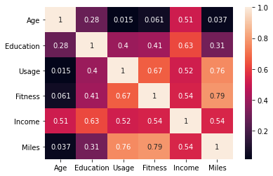

```python
sns.heatmap(cardiodata.corr(), annot=True)  # plot the correlation coefficients as a heatmap
```

**OBSERVATION 17:** Overall, we see a positive correlation for: Fitness/Miles, Usage/Miles. This means that the fitter a customer is, the more miles they're likely to run on a treadmill. Similarly, as this may be fairly obvious: the more a customer uses a treadmill, the more miles they'll run. It is interesting here, however, that there is less correlation between Usage/Fitness, ie. that a customer with high treadmill usage does not indicate high fitess, and vice versa that a customer with high fitness does not indicate high treadmill usage.</font>

Next, heatmaps by product to see if any correlation changes are there:

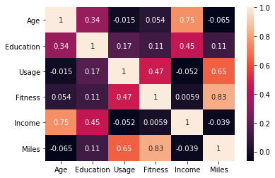

```python
sns.heatmap(cardiodata[cardiodata['Product'] == "TM195"].corr(), annot=True)  # plot the correlation coefficients as a heatmap
```

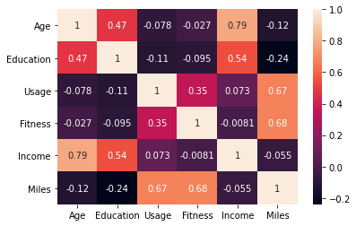

```python
sns.heatmap(cardiodata[cardiodata['Product'] == "TM498"].corr(), annot=True)  # plot the correlation coefficients as a heatmap
```

**OBSERVATION 18:** For TM195 and TM498, although the patterns in positive correlation drop a little but still remain strong, there is strong pattern here that the higher the age, the higher the income of customers. This is definitely something to note from a business standpoint when catering to higher income audiences.</font>

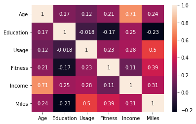

```python
sns.heatmap(cardiodata[cardiodata['Product'] == "TM798"].corr(), annot=True)  # plot the correlation coefficients as a heatmap
```

**OBSERVATION 19:** For TM798, we actually see a drop in correlation that the fitter the customer is, the more miles they'll run on the treadmill. It also looks like there's a drop in the earlier statement that higher treadmill usage indicates more miles ran. This may be due to the fact that men using this treadmill utilize the TM798 as part of their extended workout. This treadmill seems to sell well for those with established workouts ie experienced folks.</font>